# Class notes for Week 06

Author

Jae Jung

Published

October 10, 2026

# Announcement

- CEP Assignments and deadlines

# Feedback

- Our main concern is that the workload for IBM 6500 has become extremely difficult to manage. For example, during one week, students were assigned eight assignments in addition to two weekly quizzes. Each assignment can take approximately four to five hours to complete, resulting in an estimated 32 to 40 hours of work for this course in a single week. Many students in the MSDM program also work full time, take three other courses, complete certifications, and work on the CEP project.
  - Our goal is not to reduce academic expectations. We want to learn the material thoroughly, but the current workload and course structure make that difficult. We hope these concerns can be considered so that students can better manage their time and focus on meaningful learning.
  - Combining some of the smaller weekly assignments into fewer, larger assignments
  - Reducing the number of weekly assignments to approximately two or three
  - Spacing out due dates so that fewer assignments are due during the same week
  - Clarifying which assignments are most important so that students can prioritize their time effectively
- Improving the quality of the lectures by providing more explanation, examples, and instruction instead of mainly repeating the assignment requirements.
- Updating the course content and in-class instruction to reflect current developments in AI and digital marketing. (Because AI is advancing so rapidly, digital marketing requires up-to-date knowledge and industry practices. We would benefit from current topics, updated PowerPoint presentations, and direct explanations during class rather than relying primarily on an older instructional video.)
- Ending class on time and avoiding regularly going over the scheduled class period

# Use of AI for Assignments

## WSJ Article, 9/11/2026

https://www.wsj.com/tech/ai/ai-company-rules-2c5fe5bc?mod=Searchresults&pos=1&page=1

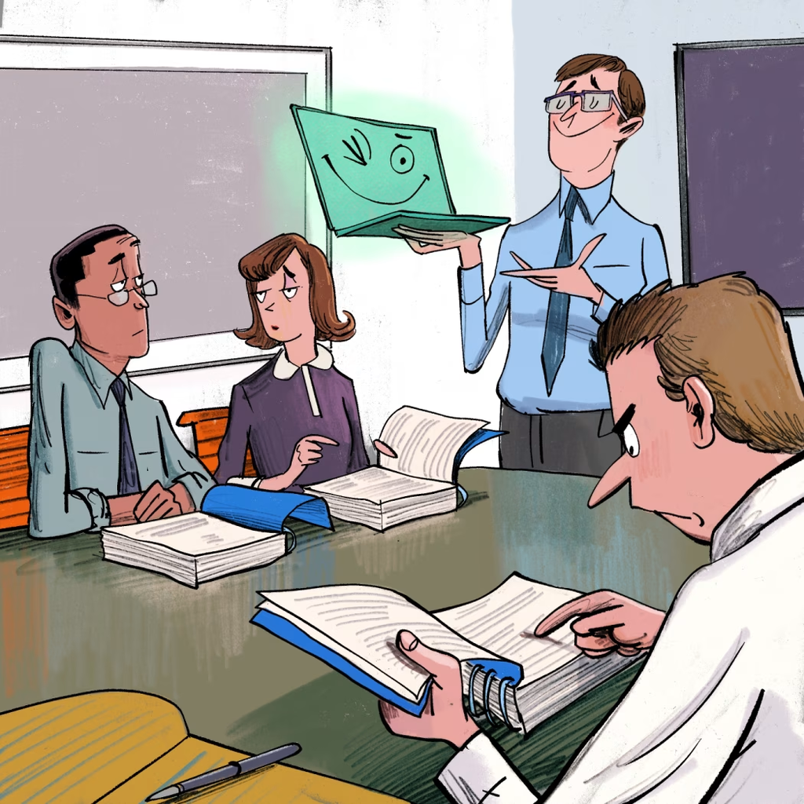

As generative AI has swept into the workplace, much of the debate has focused on how it will shape the future: Will it make us more productive? Eliminate jobs? Transform the nature of work itself?

Those questions may take years to answer. But one consequence is already becoming clear: Artificial intelligence is creating a trust problem among colleagues at work.

We don’t know what the rules around AI use are, for instance, so we often can’t tell whether our colleagues are breaking them. We don’t necessarily believe them when they say they aren’t using AI. And we judge them harshly when we suspect they are, even as we conceal our own use.

In other words, AI isn’t just changing how we work. It’s changing how we relate to—and trust—the people we work *with*. That distrust threatens to undermine the teamwork and productivity gains that AI is supposed to deliver.

Here are some of the biggest social minefields AI is creating, and what organizations can do about them.

### **No rules or norms**

Generative AI is being incorporated into the workplace at a rapid pace, as fast as the personal computer and faster than the internet was. That said, most organizations [lack rules and policies](http://deloitte.com/us/en/programs/center-for-board-effectiveness/articles/board-of-director-ai-use.html?id=us%3A2em%3A3na%3Addbod%3Aeng%3Accg%3A072226%3Amkid-K0223348&ctr=fecta&sfid=0035Y00004DcfZOQAZ) around how employees are supposed to use AI. We not only don’t know what’s technically allowed—which tasks we can outsource to AI, get a little help with, or get punished for if someone detects even a trace of it—but also, what our bosses, employees and teammates are actually doing.

What’s more, even when there are rules, many companies have norms that counter them. One [study](https://mbs.edu/faculty-and-research/trust-and-ai) of 30,000 employees found that about 40% of people used AI at work even when they aren’t supposed to.

Take Sara and her colleague Scott. Sara may not care if Scott in the cubicle next to her is using AI to write his reports. But she might care if he’s outsourcing his part of a team project to it, leaving her feeling uncertain about his ability to present his work in front of a client next week. Maybe he’s cheating. Or maybe he’s just super tech savvy and enough of an expert that outsourcing the work is just fine. Sara’s not sure what she’s supposed to make of Scott’s behavior, and she certainly doesn’t feel comfortable confronting him, not knowing what the company norms are.

### **We hide our AI use**

There is a good chance that even if Sara did confront Scott, he’ll deny at least some of it.

KPMG found that among 48,000 employees, about[57% admitted](https://kpmg.com/xx/en/media/press-releases/2025/04/trust-of-ai-remains-a-critical-challenge.html) to trying to pass AI content off as their own. And that is because despite its ubiquity, there is a very strong bias against using it. We label those who[outsource their work](https://www.sciencedirect.com/science/article/pii/S0747563225003413) to AI as lazier and less moral, and we think they value their work less than those who don’t.

If you think a work email or text was written with the help of AI, you see it as [less genuine](https://www.sciencedirect.com/science/article/pii/S0747563226001937) than those written presumably by a person, and the writer as less competent. If we think people we’re interacting with are using AI to autofill their texts with [“smart replies”](https://www.nature.com/articles/s41598-023-30938-9) (“I hope you’re doing…*really well today!*”), we see them as less cooperative and more dominant, and we like them less than if we think they finished those sentences on their own.

Yes, this makes us all hypocrites. We have no problem using AI ourselves to complete tasks faster and help navigate social encounters. But once someone’s work is labeled as AI-generated, the negative social judgments will follow.

Sara’s not just worried that Scott can’t perform in front of a client, she might also think he’s incompetent and not very motivated to do his job. She thinks he’s cheating by using AI. And unless she confronts him, these judgments will live in her mind unchallenged. We avoid confrontation at work at the best of times when we have clear rules and norms to guide us. It’s easy to imagine how quickly a workplace relationship can sour over something as simple as: Did they use AI to make that?

### **People are bad at detecting AI**

After living in a world saturated with AI content, most of us are pretty confident that we can detect the signs of AI in emails, text messages, images and reports. If Sara suspects Scott of using AI, she probably has a good reason for it.

Except she doesn’t: Despite all of this exposure, we’re no better than chance at detecting AI content—between[50% and 54%](https://www.pnas.org/doi/10.1073/pnas.2208839120) on average. Detecting AI is like trying to detect lies: In most cases, there is no single signature that gives AI away, aside from hallucinations. Instead, people rely on the wrong cues, such as how impersonal, monotonous, or how long an email is, in deciding whether AI played a role.

Sara’s judgments of Scott are based on a coin flip, and one she doesn’t know she’s made. She just knows she resents Scott for using AI.

The workplace is full of Scotts and Saras—people who are judging one another’s emails and work based on their theories of what AI content ought to look like and whether it was used appropriately. Sara’s next step might be to ask Scott to step down from his presentation, leaving Scott in the dark as to why. Or, more likely (remember our aversion for confrontation), she may simply harbor simmering resentment, poisoning their working relationship.

### **What companies can do**

What is the best way for organizations to approach the communication and trust issues that AI can create? Here are some tips.

• **Create groups that discuss how people are using AI, beyond what it was brought in for**. When organizations roll out a new AI technology, they focus on how it will affect their performance on the specific tasks it was brought in for. They rarely focus on how else it’s being used, appropriate or not.

Groups can be formed, made up of people from different backgrounds and levels of expertise, who represent the diverse ways AI is being used at the company. At the same time, the company should ask employees—anonymously—how they are using AI that may go beyond the company rules.

That survey allows companies to get a clearer picture of how AI is actually being used, rather than leaving employees to guess what their colleagues are doing and whether everyone is playing by the same rules. After all, ignorance breeds suspicion. If everyone assumes other people are secretly using AI in ways they are not supposed to, you get exactly the Sara/Scott problem.

The survey also helps management understand *why* people are violating the rules, which lets them address underlying problems instead of treating every violation as evidence that an employee is lazy or dishonest. For example, if people are uploading company materials into AI to create reports, violating data-privacy rules, it could be because they are understaffed and won’t get through their workload without doing so. Or if people are using AI to tackle an assignment, it could be because they lack skills or training for the task, but can’t or won’t admit it.

• **Develop clear norms around AI**. When organizations base their AI rules and policies around the realities of the workplace—which the survey can help determine—it’s much easier to develop clear company norms that aren’t violating these rules. The company should have a guidebook that contains a list of workplace situations in which there might be a need, or temptation, to use AI. These situations should make it clear what the black, white and gray areas are.

Shared norms take some of the guesswork, and suspicion, out of AI use: Employees know what their colleagues are permitted to do, what they are expected to disclose, and when an AI-assisted piece of work can be treated just like any other. Sara doesn’t need to decide for herself whether Scott is cheating, nor should Scott wonder whether he needs to conceal it. The organization has already established which uses are acceptable.

• **Keep everyone informed about the state of AI use at the company**. Companies regularly create quarterly or yearly reports on the state of the company and workplace attitudes. The state of AI use should be included in these reports.

Transparency interrupts the vicious cycle where people think AI use is shameful, so they hide it; that secrecy makes everyone suspicious of everyone else, which only makes AI use seem even more shameful. You couldn’t get a better recipe for creating a sour, distrusting workplace.

Clear rules and clear norms won’t eliminate every conflict over AI. But by taking the behavior out of the shadows, organizations can replace that toxic suspicion with something more conducive to trust: a shared understanding of what everyone is doing and why.

# Overview of Week 07 and More

- CEP assignments for survey data prior to Week 9
- CEP assignments for GA4 data prior to Week 9

# Week 7 Topics and Assignments

- Class Participation
- GitHub publication (two ways)
  1. using Terminal
  2. using Preview + GitHub repo Settings
- Core concepts and process
- Assignments for assigned this week

# CEP Presentation on Construct and Measurement Table and Questionnaire

- Group 1